# MAS_project_analysis

Munirdin

11/24/2021

## 3. Read the file and skip the first 6 lines with text

```r
library(lsr)
library(ggplot2)
library(dplyr)
library(car)

# load the data
data = read.csv("/Users/munirdin/Desktop/final-mas/data-3.csv", skip= 6)
head(data)
```

```
##   X.run.number. efficacy.of.type.of.mask mask initial.infected num.people
## 1             2                     0.65 true               10        200
## 2             4                     0.65 true               10        200
## 3             3                     0.65 true               10        200
## 4             2                     0.65 true               10        200
## 5             2                     0.65 true               10        200
## 6             4                     0.65 true               10        200
##   X.step. count.turtles.with..infected.
## 1       0                             0
## 2       0                             0
## 3       0                             0
## 4       1                             6
## 5       2                             8
## 6       1                             1
```

```r
# change column names with proper column names
colnames(data) <- c("run_numbers", "efficacy_of_type_of_mask", "mask_on_off",  "initial_infected","total_population", "steps_in_minutes", "infected" )

# data with final infected numbers
data1 <- subset(data,  data$steps_in_minutes==120) # to get only final number of infection after 120 steps
data1$infected_only <- data1$infected - data1$initial_infected

#subset mask on and mask off
mask_on_data <- subset(data1, data1$mask_on_off == "true" ) # to get only final number of infection

mask_off_data <- subset(data1,  select = c("mask_on_off", "initial_infected","total_population","infected","infected_only"), data1$mask_on_off =="false" )
```

## 2. Descriptive statistics

```r
# aggregate to get mean and sd values for infected persons (incubation ) based on the population in a shopping mall.

agg.mean = aggregate(mask_on_data, by = list(efficacy_of_type_of_mask =mask_on_data$efficacy_of_type_of_mask), FUN= mean)
agg.sd = aggregate(mask_on_data, by = list(efficacy_of_type_of_mask =mask_on_data$efficacy_of_type_of_mask), FUN= sd)

# to bind the mean and sd of mask on data

mean_spread_rate_mask <- cbind( efficacy_of_type_of_mask= agg.mean$efficacy_of_type_of_mask,
  mean_infected = agg.mean$infected_only,
      sd= agg.sd$infected_only,
      mean_ratio_infected =agg.mean$infected_only/agg.mean$total_population)

# aggregate to get mean and sd values of without mask data

agg.mean_off = aggregate(mask_off_data, by = list(mask_on_off =mask_off_data$mask_on_off), FUN= mean)
agg.sd_off = aggregate(mask_off_data, by = list(mask_on_off = mask_off_data$mask_on_off), FUN= sd)
# calculate the ratio of infection
ratio_mask_off <- (agg.mean_off$infected_only/agg.mean_off$total_population )
# bind the values of mask off data
mean_spread_rate_mask_off <- cbind( NA, agg.mean_off$infected_only,agg.sd_off$infected_only, (agg.mean_off$infected_only/agg.mean_off$total_population ))

#create final table
final_table <- rbind (mean_spread_rate_mask_off, mean_spread_rate_mask)
rownames(final_table) <- c("Mask Not On","Cloth mask", "Surgical mask","N95")

# finally get the summary result ^^
data.frame (final_table)
```

```
##               efficacy_of_type_of_mask mean_infected        sd
## Mask Not On                         NA        314.42 151.11035
## Cloth mask                        0.65        173.54  85.27799
## Surgical mask                     0.85         91.54  44.51334
## N95                               0.92         48.94  25.16347
##               mean_ratio_infected
## Mask Not On            0.52403333
## Cloth mask             0.28923333
## Surgical mask          0.15256667
## N95                    0.08156667
```

As the table shows if the effectiveness of mask increases, the mean and sd value of infected agents will decline. The ratio is calculated as follows (infected_only / total population ). The result indicates that the different type of mask has different effect on the spread of Covid-19. N95 is most effective.

## 3.Plotting the data

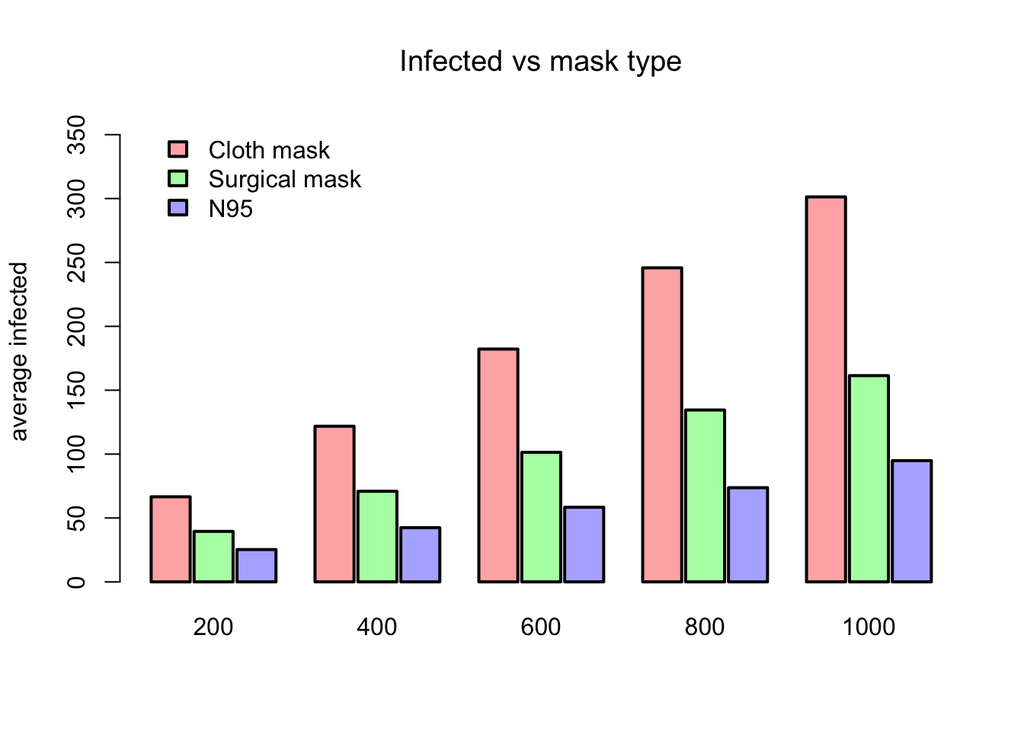

```r
#plotting average incubation numbers  based on mask type

mask_on_data$efficacy_of_type_of_mask <- as.factor(mask_on_data$efficacy_of_type_of_mask)
mask_on_data$total_population <- as.factor(mask_on_data$total_population)
bars(formula= infected ~  total_population +  efficacy_of_type_of_mask , data = mask_on_data, # bars function
     heightFun = mean,
     main = "Infected vs mask type", # title
     yLabel = "average infected",
     barSpaceSmall = .1, #space between bars
     barSpaceBig = 1, # space between bars
    errorFun = FALSE,
    legendLabels=c("Cloth mask", "Surgical mask","N95"), # name of mask
    legendLeftShift=0.7 # location of legend
  )
```

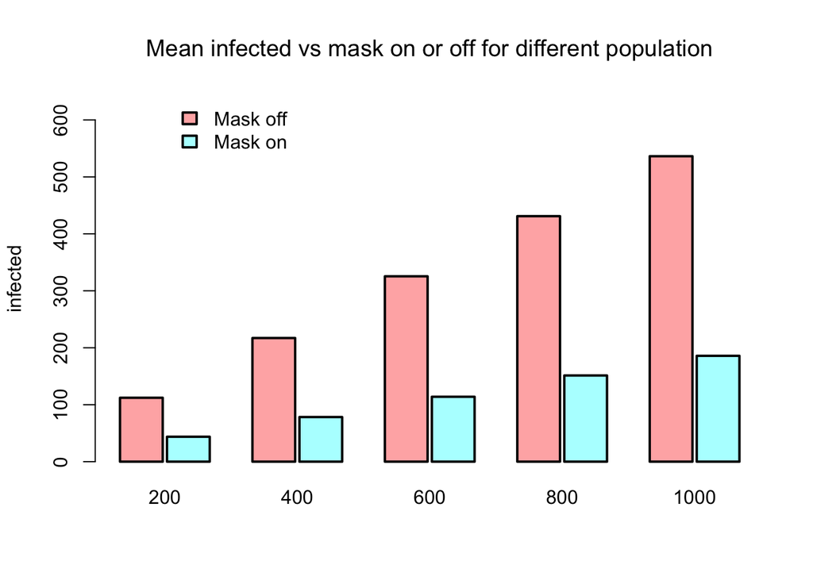

```r
#######################################################################################################################################


#plotting average incubation numbers  based on mask type

data1$mask_on_off <- as.factor(data1$mask_on_off)
data1$total_population <- as.factor(data1$total_population)

bars(formula= infected ~  total_population +  mask_on_off , data = data1, # bars function
     heightFun = mean,
     main = "Mean infected vs mask on or off for different population", # title
     barSpaceSmall = .1, #space between bars
     barSpaceBig = 1, # space between bars
    errorFun = FALSE,
    legendLabels = c("Mask off", "Mask on"),
    legendLeftShift=0.7
    )
```

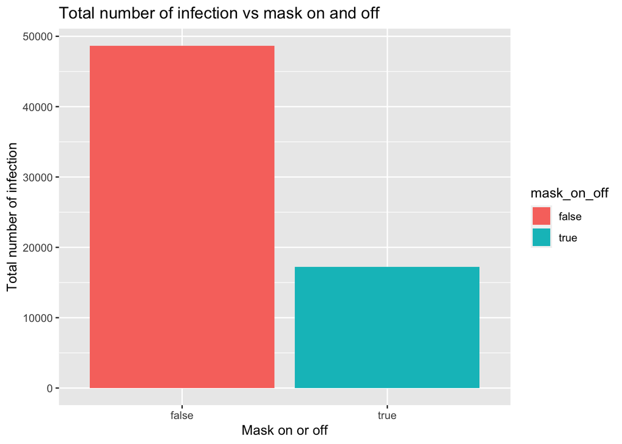

```r
##########################################################################

# plot sum of incubation per mask type

ggplot(data = data1, aes(x =  mask_on_off, y = infected, fill= mask_on_off))  +
  stat_summary(fun.y = sum, geom="bar", size = 1) +
  labs(title="Total number of infection vs mask on and off ", x ="Mask on or off", y = "Total number of infection")
```

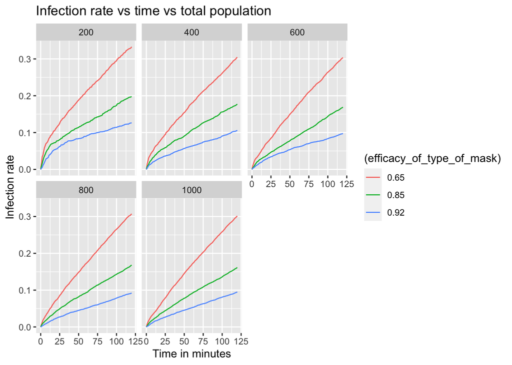

```r
###########################################################################



#create line graps per mask type vs infection rated and total population

mask_on_data_with_steps <- subset(data, data$mask_on_off =="true"  )
#prepare the data for plot
grouped_data <- mask_on_data_with_steps %>%
  group_by(efficacy_of_type_of_mask, steps_in_minutes, total_population) %>%
  summarise(mean(infected))

grouped_data <- data.frame(grouped_data )
colnames(grouped_data) <- c("efficacy_of_type_of_mask", "steps_in_minutes","total_population","mean_infected" )
grouped_data$infection_rate <- grouped_data$mean_infected / grouped_data$total_population
grouped_data$efficacy_of_type_of_mask <-as.factor(grouped_data$efficacy_of_type_of_mask)
grouped_data$total_population <- as.factor(grouped_data$total_population)

# create face_wrap with  3 different categorical values ( steps_in_minutes, total_population, efficacy_of_type_of_mask)
ggplot() +
  geom_line(data = grouped_data, aes(x= steps_in_minutes , y = infection_rate, color=(efficacy_of_type_of_mask ))) +
  labs( title = "Infection rate vs time vs total population ", x="Time in minutes", y ="Infection rate" ) +
  facet_wrap(~ total_population) +
  theme_set(theme_classic())
```

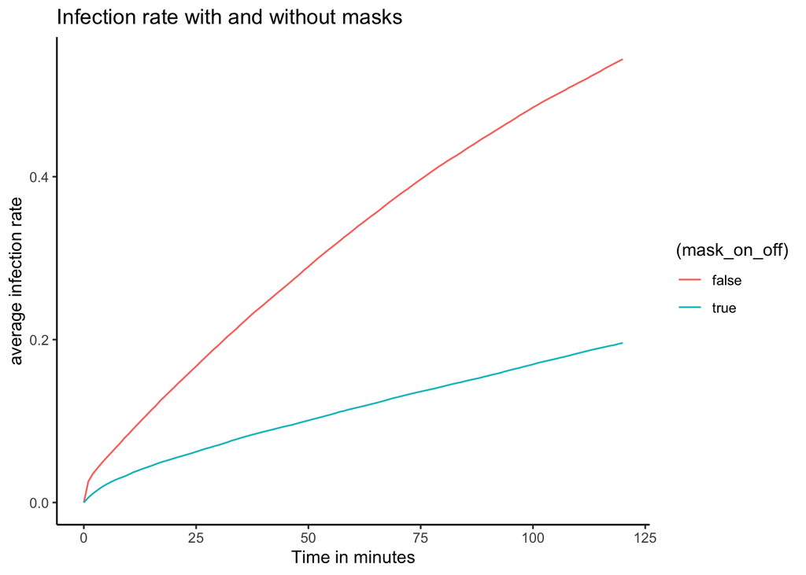

```r
#################################################################################

# mean number of infection mask on and off( using data1)


mask_with_without <-  data %>%
  group_by(mask_on_off, steps_in_minutes) %>%
  summarise(mean(infected/total_population))
mask_with_without <- data.frame(mask_with_without )

mask_with_without$infection_rate <- mask_with_without$mean.infected. / mask_with_without$mean.infected.total_population.
colnames(mask_with_without) <- c("mask_on_off", "steps_in_minutes","mean_infection_rate")
mask_with_without$mask_on_off <-as.factor(mask_with_without$mask_on_off)
# plot the data
ggplot() +
  geom_line(data = mask_with_without, aes(x= steps_in_minutes , y = mean_infection_rate, color=(mask_on_off ))) +
   labs( title = "Infection rate with and without masks ", x="Time in minutes", y ="average infection rate" )
```

The different types of plots illustrates the data more clearly. In every plot the effect of wearing mask can be seen.

## 4. differences in numbers

```r
# to calculate the difference between mask on and off  as ratio between infected population and total population
#  to calcute the differences between mask on and off we need the numbers from time steps 120
data_for_effect <- subset(data,  data$steps_in_minutes==120)
data_for_effect$infected_only <- data_for_effect$infected - data1$initial_infected

# group the data by mask_on_off and total_population. This is important to calculate the differences between
# mask on and not on.

mask_effect <-  data_for_effect %>%
  group_by(mask_on_off, total_population) %>%
  summarise(mean(infected_only/total_population))
colnames(mask_effect) <-c("mask_on_off","total_population", "mean_spread_rate")
mask_effect <- data.frame(mask_effect )

mask_on_rate <- subset (mask_effect, mask_effect$mask_on_off == "true")
mask_off_rate <- subset (mask_effect, mask_effect$mask_on_off == "false")

differences <- (mask_off_rate$mean_spread_rate - mask_on_rate$mean_spread_rate )*100

data.frame(cbind(population_size = mask_on_rate$total_population, differences))
```

```
##   population_size differences
## 1             200    34.20000
## 2             400    34.68333
## 3             600    35.23889
## 4             800    34.96667
## 5            1000    35.04333
```

These numbers represent the mean ratio between infected populations and total population. The difference between mask on and off by each population size is calculated. For each population size, the differences are approximately (35%) and this means that wearing mask can on average 35% reduce the spread of Covid-19 for each population size.The reason why this number the same for all population is that in this experiment the number of infected agent is controlled at 10 and the population size and infected_only are positive correlated. 35% is average percentage of effectiveness of three types of mask combined. Generally, Covid-19 spreads in multiple ways, but in this experiment, the spread of covid-19 is calculated only for agent to agent. If this experiment could include all possibilities of spread, the effectiveness of wearing mask would be higher, because wearing a mask can prevent people touching their faces. sum up, 35% is only for agent-to-agent with some assumptions.

## 5. Hypothesis testing

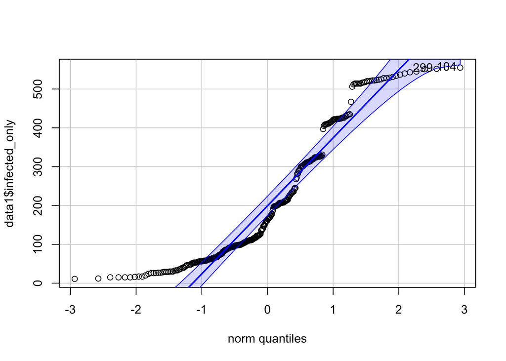

```
## [1] 104 299
```

```r
# Ho: Wearing mask indoor area is not effective (mu1= mu2)
# Ha: Wearing mask indoor area is effective ( mu is not equal to mu2)

# check normality of variables mask_on_data$infectd and mask_off_data$infected

qqPlot(data1$infected_only)
```

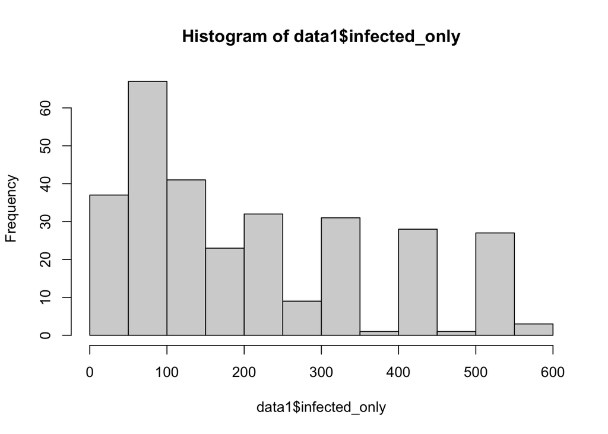

```r
hist( data1$infected_only)
```

```r
shapiro.test(data1$infected_only)
```

```
##
##  Shapiro-Wilk normality test
##
## data:  data1$infected_only
## W = 0.89329, p-value = 1.126e-13
```

```r
#run Welch's independent samples t-test for Ho

independentSamplesTTest(formula = infected ~ mask_on_off, data= data1, var.equal = FALSE)
```

```
##
##    Welch's independent samples t-test
##
## Outcome variable:   infected
## Grouping variable:  mask_on_off
##
## Descriptive statistics:
##               false    true
##    mean     324.420 114.673
##    std dev. 151.110  77.092
##
## Hypotheses:
##    null:        population means equal for both groups
##    alternative: different population means in each group
##
## Test results:
##    t-statistic:  15.143
##    degrees of freedom:  221.64
##    p-value:  <.001
##
## Other information:
##    two-sided 95% confidence interval:  [182.45, 237.043]
##    estimated effect size (Cohen's d):  1.749
```

```r
# Run linear regression to see the effect of categorical variable on depended variable( infected_only)

model <- lm(infected_only ~ efficacy_of_type_of_mask  +  total_population + mask_on_off , data = data1)

# Analysis of Variance Table to detect the effect of each variable on target variable

anova(model)
```

```
## Analysis of Variance Table
##
## Response: infected_only
##                           Df  Sum Sq Mean Sq F value    Pr(>F)
## efficacy_of_type_of_mask   1  202801  202801  55.874 8.987e-13 ***
## total_population           4 3021568  755392 208.119 < 2.2e-16 ***
## mask_on_off                1 3299525 3299525 909.058 < 2.2e-16 ***
## Residuals                293 1063475    3630
## ---
## Signif. codes:  0 '***' 0.001 '**' 0.01 '*' 0.05 '.' 0.1 ' ' 1
```

```r
# to see the effect size
etaSquared(model)
```

```
##                              eta.sq eta.sq.part
## efficacy_of_type_of_mask 0.02672871   0.1601552
## total_population         0.39823666   0.7396662
## mask_on_off              0.43487078   0.7562515
```

```r
# summary of model
summary(model)
```

```
##
## Call:
## lm(formula = infected_only ~ efficacy_of_type_of_mask + total_population +
##     mask_on_off, data = data1)
##
## Residuals:
##     Min      1Q  Median      3Q     Max
## -147.45  -43.64   13.70   43.12  121.80
##
## Coefficients:
##                          Estimate Std. Error t value Pr(>|t|)
## (Intercept)               356.196     25.963  13.719  < 2e-16 ***
## efficacy_of_type_of_mask -227.260     30.403  -7.475 8.99e-13 ***
## total_population400        69.733     10.999   6.340 8.68e-10 ***
## total_population600       141.717     10.999  12.884  < 2e-16 ***
## total_population800       213.200     10.999  19.383  < 2e-16 ***
## total_population1000      283.083     10.999  25.736  < 2e-16 ***
## mask_on_offtrue          -209.747      6.957 -30.151  < 2e-16 ***
## ---
## Signif. codes:  0 '***' 0.001 '**' 0.01 '*' 0.05 '.' 0.1 ' ' 1
##
## Residual standard error: 60.25 on 293 degrees of freedom
## Multiple R-squared:  0.8598, Adjusted R-squared:  0.857
## F-statistic: 299.6 on 6 and 293 DF,  p-value: < 2.2e-16
```

## Summary of inferential statistics

To determine the significance of the effect of the mask on an indoor area, a Welch’s independent samples t-test is conducted on the sample data. The target variable ( infected_only) is not normally distributed, but the T-test can still be run because the sample size is large enough. The test result shows(t(221.64)= 15.143, p <.001, Cl95 = [182.45, 237.043] ) that there is enough evidence that the wearing mask in an indoor area has an effect.

The summary function is run on the result of linear regression model. for whole model, all categorical variables have effect on spread of covid-19((F(6,293)=299.6, p-value: < 2.2e-16, R-squared = 0.857).

To conclude, each categorical variable in this experiment ( mask_on_off, total_population, efficacy_of_type_of_mask) has a effect on the spread of covid-19 virus.